# DADA2 Tuto nb

##Installer et faire apparaitre en tête le package DADA2.

```r
install.packages("Rcpp")
library(dada2)
packageVersion("dada2")
```

Ici, on cherche à créer le vecteur path qui contiendra l’ensemble des fichiers de séquence sur lesquels travailler.

```r
path<- "/home/rstudio/DADA2/MiSeq_SOP"
print(path)
list.files(path)
```

Dans deux vecteurs différents, on assigne respectivement l’ensemble des sequences forward (fnFs) et reverse (fnRs).

```r
fnFs<-sort(list.files(path, pattern="_R1_001.fastq", full.names=TRUE))
print(fnFs)
fnRs<-sort(list.files(path, pattern="_R2_001.fastq",full.names=TRUE))
print(fnRs)
```

Le vecteur “sample.names” sera défini comme les noms des échantillons selon la première partie du nom de fichier si on considère le caractère “_” comme séparateur. Ainsi on a : F3D0_s188_L001_R1_001.fastq aura le nom F3D0.

```r
sample.names<-sapply(strsplit(basename(fnFs),"_"),`[`, 1)
sample.names
```

##Profil de qualité des séquences

Ces graphiques présente les scores de qualité pour l’ensemble des bases des séquences 1 et 2 Forward et reverse.

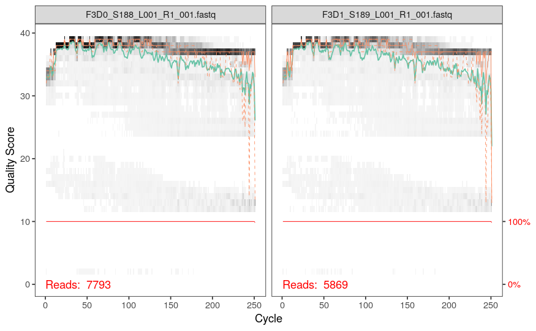

```r
plotQualityProfile(fnFs[1:2])
```

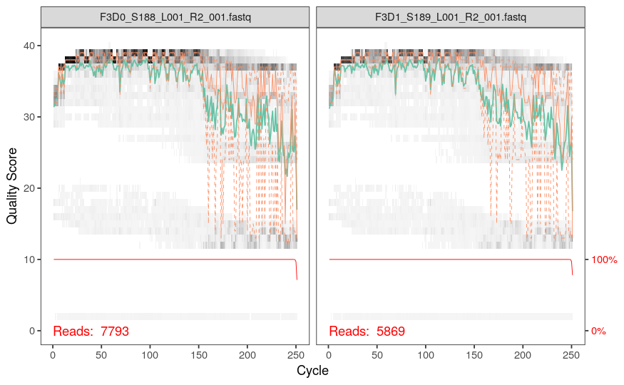

```r
plotQualityProfile(fnRs[1:2])
```

#Filtrer les séquences.

L’objectif de cette partie est de supprimer les séquences de mauvaise qualité identifiées grâce aux graphiques précedents. On créé donc deux nouveaux vecteurs de séquences filtrées (filtF/Rs) en y assignant le chemin pour aller jusqu’aux fichiers de séquences dans le dossier “filtered” et assignant comme nom d’échantillons les noms utiliser dans la variable “sample.names” suivi de la précision “_f/R_filt.fastq.gz” pour identifier les séquences filtrées.

```r
filtFs<-file.path(path,"filtered",paste0(sample.names,"_F_filt.fastq.gz"))
filtRs<-file.path(path,"filtered",paste0(sample.names,"_R_filt.fastq.gz"))
```

La fonction suivante permettra de réunir dans un seul vecteur les parametres de filtre. Ainsi pour les fichier fnF/Rs et filtF/Rs, on va couper les séquences après 240pb pour les seq F, et 160pb pour les seq R, qui permet toujours un chevauchement des 2 séquences pour les aligner tout en éliminant les pb de mauvaises qualité aux extrémités des séquences. MaxN/EE et truncQ sont des valeurs standards, rm.phix permet de supprimer les séquences du gène phagique phi X ajouter avant séquençage.

```r
out<-filterAndTrim(fnFs, filtFs, fnRs, filtRs, truncLen=c(240,160),maxN=0,maxEE=c(2,2),truncQ=2,rm.phix=TRUE,compress=TRUE,multithread=TRUE)
```

La fonction “head” permet de comparé le nombre de séquence avant et après filtration des séquences.

```r
head(out)
```

[output not shown]

##Apprendre les erreurs.

Le but de ce vecteur est d’évaluer les taux d’erreurs de séquençage. On assigne aux deux fonctions suivantes d’apprendre des erreurs sur les séquences F et R.

```r
errF<-learnErrors(filtFs, multithread=TRUE)
errR<-learnErrors(filtRs, multithread=TRUE)
```

Cela permet par la suite d’établir des graphiques d’estimation du taux d’erreur en fonction de la base à partir du jeu de données.

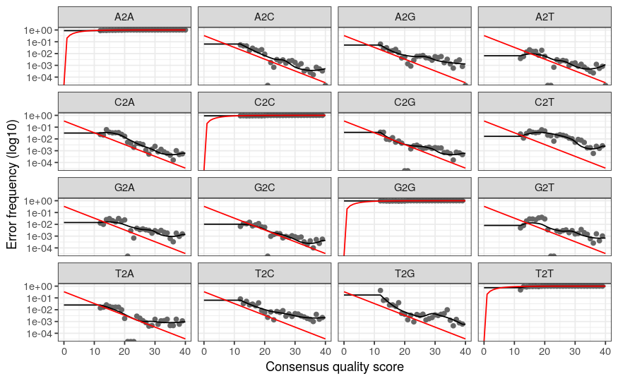

```r
plotErrors(errF,nominalQ=TRUE)
```

# Sample Inference

Cette étape permet d’identifier les séquences uniques parmis l’ensemble des échantillons.

Le vecteur dadaF/Rs sera assigné par la fonction dada qui permet de supprimer les erreurs de séquençage des fichier de séquences filtrées en applicant le taux d’erreur appris précédemment.

```r
dadaFs<-dada(filtFs, err=errF, multithread=TRUE)
dadaRs<-dada(filtRs, err=errR, multithread=TRUE)
```

La fonction suivante permet d’afficher le nombre de séquences uniques identifiées ainsi que le nombre de variants identifiés parmis ces séquences uniques pour un échantillon.

```r
dadaFs[[16]]
```

[output not shown]

##Rassembler les séquences.

Ici, la fonction mergePairs est assigné au vecteur mergers dans le but de rassembler l’ensemble des séquences dans un tableau et de les comparés.

```r
mergers<-mergePairs(dadaFs,filtFs,dadaRs,filtRs, verbose=TRUE)
```

```
6540 paired-reads (in 107 unique pairings) successfully merged out of 6891 (in 197 pairings) input.
5028 paired-reads (in 101 unique pairings) successfully merged out of 5190 (in 157 pairings) input.
4986 paired-reads (in 81 unique pairings) successfully merged out of 5267 (in 166 pairings) input.
2595 paired-reads (in 52 unique pairings) successfully merged out of 2754 (in 108 pairings) input.
2553 paired-reads (in 60 unique pairings) successfully merged out of 2785 (in 119 pairings) input.
3646 paired-reads (in 55 unique pairings) successfully merged out of 4109 (in 157 pairings) input.
6079 paired-reads (in 81 unique pairings) successfully merged out of 6514 (in 198 pairings) input.
3968 paired-reads (in 91 unique pairings) successfully merged out of 4388 (in 187 pairings) input.
14233 paired-reads (in 143 unique pairings) successfully merged out of 15355 (in 352 pairings) input.
10528 paired-reads (in 120 unique pairings) successfully merged out of 11165 (in 278 pairings) input.
11154 paired-reads (in 137 unique pairings) successfully merged out of 11797 (in 298 pairings) input.
4349 paired-reads (in 85 unique pairings) successfully merged out of 4802 (in 179 pairings) input.
17431 paired-reads (in 153 unique pairings) successfully merged out of 17812 (in 272 pairings) input.
5850 paired-reads (in 81 unique pairings) successfully merged out of 6095 (in 159 pairings) input.
3716 paired-reads (in 86 unique pairings) successfully merged out of 3894 (in 147 pairings) input.
6865 paired-reads (in 99 unique pairings) successfully merged out of 7191 (in 187 pairings) input.
4426 paired-reads (in 67 unique pairings) successfully merged out of 4603 (in 127 pairings) input.
4576 paired-reads (in 101 unique pairings) successfully merged out of 4739 (in 174 pairings) input.
6092 paired-reads (in 109 unique pairings) successfully merged out of 6315 (in 173 pairings) input.
4269 paired-reads (in 20 unique pairings) successfully merged out of 4281 (in 28 pairings) input.
```

```r
head(mergers[[1]])
```

|  | sequence | abundance | forward | reverse | nmatch | nmismatch | nindel | prefer | accept |
| --- | --- | --- | --- | --- | --- | --- | --- | --- | --- |
| 1 | TACGGAGGATGCGAGCGTTATCCGGATTTATTGGGTTTAAAGGGTGCGCAGGCGGAAGAT…… | 579 | 1 | 1 | 148 | 0 | 0 | 1 | TRUE |
| 2 | TACGGAGGATGCGAGCGTTATCCGGATTTATTGGGTTTAAAGGGTGCGTAGGCGGCCTGC…… | 470 | 2 | 2 | 148 | 0 | 0 | 2 | TRUE |
| 3 | TACGGAGGATGCGAGCGTTATCCGGATTTATTGGGTTTAAAGGGTGCGTAGGCGGGCTGT…… | 449 | 3 | 4 | 148 | 0 | 0 | 1 | TRUE |
| 4 | TACGGAGGATGCGAGCGTTATCCGGATTTATTGGGTTTAAAGGGTGCGTAGGCGGGCTTT…… | 430 | 4 | 3 | 148 | 0 | 0 | 2 | TRUE |
| 5 | TACGGAGGATGCGAGCGTTATCCGGATTTATTGGGTTTAAAGGGTGCGCAGGCGGACTCT…… | 345 | 5 | 6 | 148 | 0 | 0 | 1 | TRUE |
| 6 | TACGGAGGATGCGAGCGTTATCCGGATTTATTGGGTTTAAAGGGTGCGTAGGCGGGATGC…… | 282 | 6 | 5 | 148 | 0 | 0 | 2 | TRUE |

##Construction de la table de séquence.

```r
table(nchar(getSequences(seqtab)))
```

```
251 252 253 254 255
  1  88 196   6   2
```

##Suppression des séquences chimères.

L’objectif de ces fonctions est d’assigner au tableau “seqtab.nochim” l’ensemble des séquences considérées comme non-chimériques par comparaison de l’ensemble des séquences du séquençage effectué et d’en décrire le nombre de ligne et de colonne.

```r
seqtab.nochim <- removeBimeraDenovo(seqtab, method="consensus", multithread=TRUE, verbose=TRUE)
```

```
Identified 61 bimeras out of 293 input sequences.
```

```r
dim(seqtab.nochim)
```

```
[1]  20 232
```

```r
sum(seqtab.nochim)/sum(seqtab)
```

```
[1] 0.9640374
```

##Résumé du nombre de séquences à chacune des étapes.

Les fonctions suivantes permettent de présenter un tableau présentant le nombre de séquences retenues à chaque étape (données brutes, filtration, suppression des chimères, …)

```r
getN <- function(x) sum(getUniques(x))
track <- cbind(out, sapply(dadaFs, getN), sapply(dadaRs, getN), sapply(mergers, getN), rowSums(seqtab.nochim))
colnames(track) <- c("input", "filtered", "denoisedF", "denoisedR", "merged", "nonchim")
rownames(track) <- sample.names
head(track)
```

```
       input filtered denoisedF denoisedR merged nonchim
F3D0    7793     7113      6976      6979   6540    6528
F3D1    5869     5299      5227      5239   5028    5017
F3D141  5958     5463      5331      5357   4986    4863
F3D142  3183     2914      2799      2830   2595    2521
F3D143  3178     2941      2822      2868   2553    2519
F3D144  4827     4312      4151      4228   3646    3507
```

##Assignement des taxonomies.

Grâce à la base de données Silva v132, il est possible d’assigner des taxonomies aux séquences retenues. Ces taxonomies sont assignées au vecteur “Taxa” à partir de la table de séquences non chimériques.

```r
taxa <- assignTaxonomy(seqtab.nochim, "~/DADA2/silva_nr_v132_train_set.fa.gz", multithread=TRUE)
```

Cela permet par la suite d’identifier et de présenter dans une table le taxon retrouvés dans les échantillons.

```r
taxa.print<-taxa
rownames(taxa.print)<-NULL
head(taxa.print)
```

```
     Kingdom    Phylum          Class         Order           Family           Genus
[1,] "Bacteria" "Bacteroidetes" "Bacteroidia" "Bacteroidales" "Muribaculaceae" NA
[2,] "Bacteria" "Bacteroidetes" "Bacteroidia" "Bacteroidales" "Muribaculaceae" NA
[3,] "Bacteria" "Bacteroidetes" "Bacteroidia" "Bacteroidales" "Muribaculaceae" NA
[4,] "Bacteria" "Bacteroidetes" "Bacteroidia" "Bacteroidales" "Muribaculaceae" NA
[5,] "Bacteria" "Bacteroidetes" "Bacteroidia" "Bacteroidales" "Bacteroidaceae" "Bacteroides"
[6,] "Bacteria" "Bacteroidetes" "Bacteroidia" "Bacteroidales" "Muribaculaceae" NA
```

##Evaluer la précision.

Afin d’évaluer la précision, il faut utiliser l’échantillon Mock ajouté à composition et concentration connue, dont on ajoute les séquences à partir de la table seqtab.nochim au vecteur unqs.mock. Par la suite, on trie les séquences (sort) du vecteur unqs.mock suivant la longueur des séquences qu’il contient. La fonction “cat” permet d’afficher le résultat du nombre de séquences de l’échantillon Mock.

```r
unqs.mock<-seqtab.nochim["Mock_F_filt.fastq.gz",]

unqs.mock <- sort(unqs.mock[unqs.mock>0], decreasing=TRUE)

cat("DADA2 inferred", length(unqs.mock), "sample sequences present in the Mock community.\n")
```

```
DADA2 inferred 20 sample sequences present in the Mock community.
```

On créé par la suite un vecteur de référence de l’échantillon Mock avec le fichier contenant l’ensemble des séquences qui doivent être retrouvées (HMP_MOCK.v35.fasta). La fonction match.ref permet de comparer l’échantillon de référence Mock (mock.ref) avec l’échantillon mock séquencé. La fonction “cat” permet d’afficher la somme des séquences de l’échantillon Mock concordante avec l’échantillon de reférence (mock.ref).

```r
mock.ref<-getSequences(file.path(path, "HMP_MOCK.v35.fasta"))

match.ref<-sum(sapply(names(unqs.mock), function(x) any(grepl(x, mock.ref))))

cat("Of those,", sum(match.ref), "were exact matches to the expected reference sequences.\n")
```

```
Of those, 20 were exact matches to the expected reference sequences.
```

##Utilisation de Phyloseq.

```r
library(phyloseq)
library(Biostrings)
library(ggplot2)
theme_set(theme_bw())
```

##Construction d’un tableau de données.

Ici, il faut créer un tableau de données présentant le nom, le genre, et le jour de chacun des échantillons.

```r
samples.out <- rownames(seqtab.nochim)

subject <- sapply(strsplit(samples.out, "D"), `[`, 1)

gender <- substr(subject,1,1)

subject <- substr(subject,2,999)

day <- as.integer(sapply(strsplit(sample.names, "D"), `[`, 2))

samdf <- data.frame(Subject=subject, Gender=gender, Day=day)

samdf$When <- "Early"

samdf$When[samdf$Day>100] <- "Late"

rownames(samdf) <- samples.out
```

```r
ps
```

```
phyloseq-class experiment-level object
otu_table()   OTU Table:         [ 232 taxa and 19 samples ]
sample_data() Sample Data:       [ 19 samples by 4 sample variables ]
tax_table()   Taxonomy Table:    [ 232 taxa by 6 taxonomic ranks ]
```

```r
print(ps)
```

```
phyloseq-class experiment-level object
otu_table()   OTU Table:         [ 232 taxa and 19 samples ]
sample_data() Sample Data:       [ 19 samples by 4 sample variables ]
tax_table()   Taxonomy Table:    [ 232 taxa by 6 taxonomic ranks ]
```

##Analyse des différences entre les échantillons prélevés à t<100jours VS t>100jours.

Les graphiques suivant décrivent la diversité alpha des communautés en fonction du jour ou à été prélevé l’échantillon (<100 jours VS >100 jours). On distingue une plus faible diversité des communautés dans les échantillons prélevés à t>100jours mais ces communautés reste plus similaires que celles à t<100jours qui restent différentes (points éparpillés).

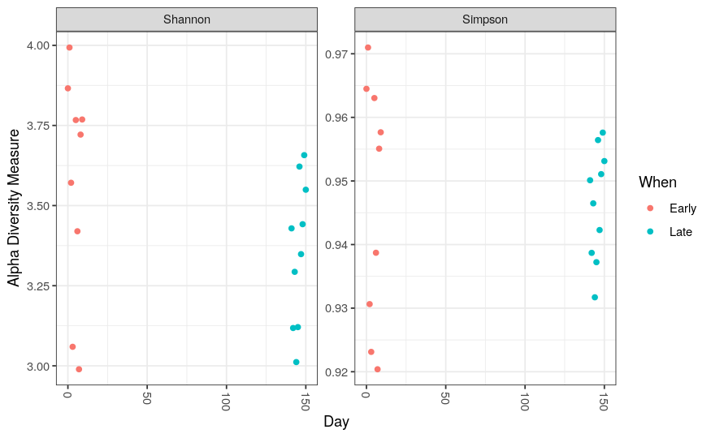

```r
plot_richness(ps, x="Day", measures=c("Shannon", "Simpson"), color="When")
```

```r
ps.prop<-transform_sample_counts(ps,function(otu)otu/sum(otu))

ord.nmds.bray<- ordinate(ps.prop, method="NMDS", distance="bray")
```

```
*** Best solution repeated 3 times
```

Le graphique d’ordination ci-dessous permet d’identifier une corrélation entre la plupart des échantillons prélevés à t<100jours mais aussi entre les échantillons prélevés à t>100jours. On observe aussi une séparation entre les deux temps de prélèvement.

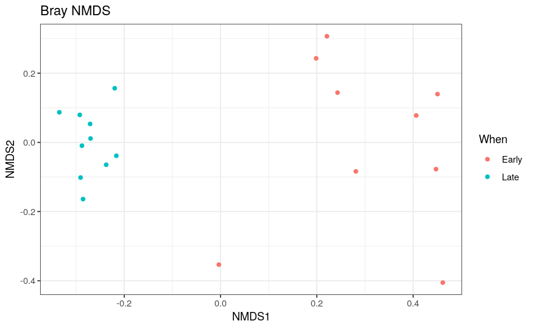

```r
plot_ordination(ps.prop, ord.nmds.bray, color="When", title="Bray NMDS")
```

Les bar plots suivant décrivent les différentes familles bactériennes identifiés dans les échantillons <100 jours et >100 jours. Pour tous les échantillons, on retrouve majoritairement la famille des Muribaculaceae.

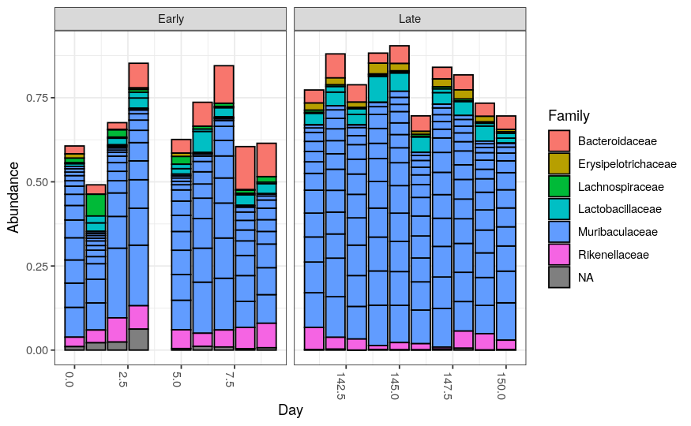

```r
top20 <- names(sort(taxa_sums(ps), decreasing=TRUE))[1:20]

ps.top20 <- transform_sample_counts(ps, function(OTU) OTU/sum(OTU))

ps.top20 <- prune_taxa(top20, ps.top20)

plot_bar(ps.top20, x="Day", fill="Family") + facet_wrap(~When, scales="free_x")
```